# Coursera: Regression Models - Project

Motor Trend Car Road Tests

Sumant Sharma

### Executive Summary

In this project we work for Motor Trend, a magazine about the automobile industry. Looking at a data set of a collection of cars, we explor the relationship between a set of variables and miles per gallon (MPG) (outcome). We are particularly interested in the following two questions:

### Solution

#### 1. Data Dictionary

This dataset was extracted from the 1974 Motor Trend US magazine which comprises of 11 aspects of automobile design and performance for 32 automobiles. Refer Table 1(Appendix - A) for the dataset.

```r
data(mtcars)
head(mtcars)
```

#### 2. Data Transformation

The first step to build any data model is to cleanse the data. As part of data cleansing, we transformed and factored the following categorical variables.

```r
data(mtcars)
mtcars$cyl <- factor(mtcars$cyl)
mtcars$vs <- factor(mtcars$vs)
mtcars$gear <- factor(mtcars$gear)
mtcars$carb <- factor(mtcars$carb)
mtcars$am <- factor(mtcars$am,labels=c('Automatic','Manual'))
```

#### 3. Data Exploration

Once data transformation was complete, we used multiple data exploration tools such as scatterplots, histograms etc. to identifying meaningful relationships among variables.

`scatterPlotMatrix(mtcars)`

From the Plot 1(Appendix - B) we notice that variables like `cyl`, `disp`, `hp`, `drat`, `wt`, `vs` and `am` seem to have some strong correlation with `mpg`. We also plot a boxplot of the variable `mpg` grouped by `am`. Plot 2(Appendix - B) shows that the mpg is higher when the transmission is ‘Manual’.

```
library(ggplot2)
p <- ggplot(mtcars, aes(am, mpg))
p + geom_boxplot(aes(fill=am))
```

#### 4. Data Modeling

Let’s investigate the relationship between miles per gallon and transmission type. First we run a regression model with `mpg` as the response variable and `am` as the (only) explanatory variable.

```r
mod1<-lm(mpg ~ am, data = mtcars)
summary(mod1)$coef
```

Table 2(Appendix - A) shows that the model explains only 35% of the total variation in `mpg` and there are additional variables in our data; there is a chance that we could find a better model. So we run the regression model multiple times using STEP method to build multiple regression models using both forward selection and backward elimination methods by the AIC algorithm.

```r
mod2<-lm(mpg ~ ., data = mtcars)
mod3<-step(mod2, direction = "both")
summary(mod3)
```

```r
anova(mod1, mod3)
```

#### 5. Residuals

`par(mfrow = c(2,2)) plot(mod3)` Plot 3(Appendix - B) depicts that the residual plots are randomly scattered.

#### Appendix - A

```
##                    mpg cyl disp  hp drat    wt  qsec vs am gear carb
## Mazda RX4         21.0   6  160 110 3.90 2.620 16.46  0  1    4    4
## Mazda RX4 Wag     21.0   6  160 110 3.90 2.875 17.02  0  1    4    4
## Datsun 710        22.8   4  108  93 3.85 2.320 18.61  1  1    4    1
## Hornet 4 Drive    21.4   6  258 110 3.08 3.215 19.44  1  0    3    1
## Hornet Sportabout 18.7   8  360 175 3.15 3.440 17.02  0  0    3    2
## Valiant           18.1   6  225 105 2.76 3.460 20.22  1  0    3    1
```

Table 1: mtcars dataset

```
##
## Call:
## lm(formula = mpg ~ am, data = mtcars)
##
## Residuals:
##     Min      1Q  Median      3Q     Max
## -9.3923 -3.0923 -0.2974  3.2439  9.5077
##
## Coefficients:
##             Estimate Std. Error t value Pr(>|t|)
## (Intercept)   17.147      1.125  15.247 1.13e-15 ***
## amManual       7.245      1.764   4.106 0.000285 ***
## ---
## Signif. codes:  0 '***' 0.001 '**' 0.01 '*' 0.05 '.' 0.1 ' ' 1
##
## Residual standard error: 4.902 on 30 degrees of freedom
## Multiple R-squared:  0.3598, Adjusted R-squared:  0.3385
## F-statistic: 16.86 on 1 and 30 DF,  p-value: 0.000285
```

Table 2: Summary of the model with `mpg` as the response variable with `am` as predictor.

```
##
## Call:
## lm(formula = mpg ~ cyl + hp + wt + am, data = mtcars)
##
## Residuals:
##     Min      1Q  Median      3Q     Max
## -3.9387 -1.2560 -0.4013  1.1253  5.0513
##
## Coefficients:
##             Estimate Std. Error t value Pr(>|t|)
## (Intercept) 33.70832    2.60489  12.940 7.73e-13 ***
## cyl6        -3.03134    1.40728  -2.154  0.04068 *
## cyl8        -2.16368    2.28425  -0.947  0.35225
## hp          -0.03211    0.01369  -2.345  0.02693 *
## wt          -2.49683    0.88559  -2.819  0.00908 **
## amManual     1.80921    1.39630   1.296  0.20646
## ---
## Signif. codes:  0 '***' 0.001 '**' 0.01 '*' 0.05 '.' 0.1 ' ' 1
##
## Residual standard error: 2.41 on 26 degrees of freedom
## Multiple R-squared:  0.8659, Adjusted R-squared:  0.8401
## F-statistic: 33.57 on 5 and 26 DF,  p-value: 1.506e-10
```

Table 3: Summary of the model with `mpg` as the response variable by `step` method.

```
## Analysis of Variance Table
##
## Model 1: mpg ~ am
## Model 2: mpg ~ cyl + hp + wt + am
##   Res.Df    RSS Df Sum of Sq      F    Pr(>F)
## 1     30 720.90
## 2     26 151.03  4    569.87 24.527 1.688e-08 ***
## ---
## Signif. codes:  0 '***' 0.001 '**' 0.01 '*' 0.05 '.' 0.1 ' ' 1
```

Table 4: Analysis of variance between `mod1` and `mod3`

#### Appendix - B

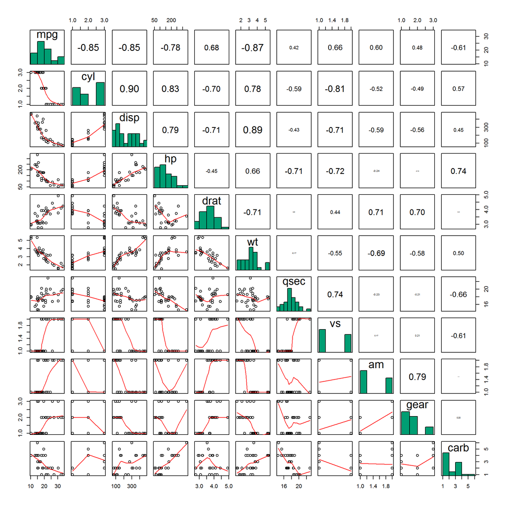

Plot 1: Scatterplot matrix with correlation and frequency plot.

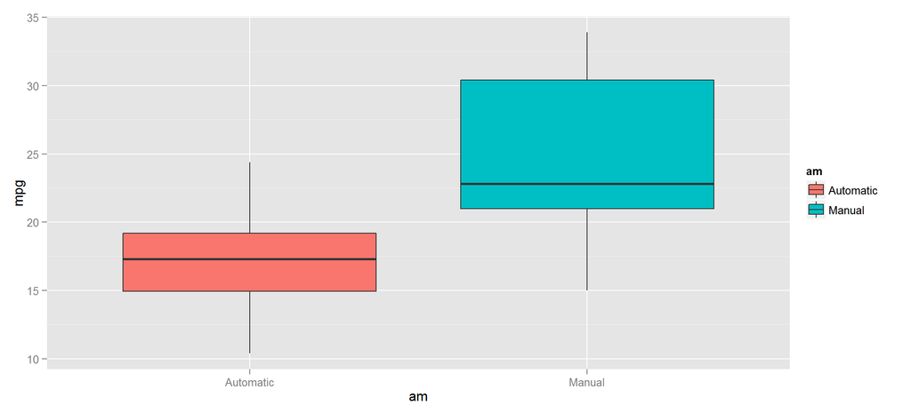

Plot 2: Boxplot of `miles per gallon` grouped by `transmission`.

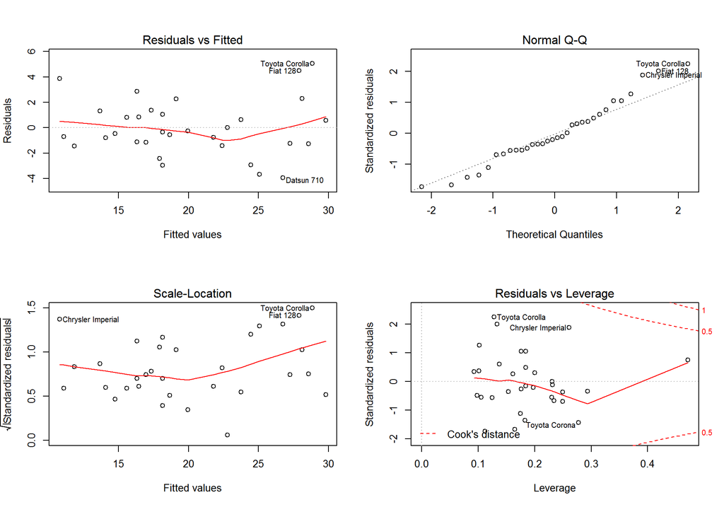

Plot 3: Residual plot for the best model `mod3`